# **CSCN8010 - Section2**

### Practical Lab 1

#### Univariate Linear Regression on the California Housing Prices Dataset

Prepared by : Nikhil Shankar Chirakkal Sivasankaran (9026254)

## **1. Introduction**

This notebook aims to explore the possibility of predicting house values using the dataset available from Kaggle. The dataset consists of data from 1990 census of housing in California state districts in USA. The aim of this analysis is to find if there is any possibility of creating a machine learning model specifically Linear Regression Model from 3 of the variables that are present in the dataset namely Median Income, Population and No. of Households. The study aims to analyse 3 Linear Regression Models and its usability in predicting the housing prices.

## **2. Data Exploration**

> Dataset Link : [Kaggle California Housing Price Dataset](https://www.kaggle.com/datasets/camnugent/california-housing-prices)

##### **2.1 Dataset Overview**

What are the variables or columns in the dataset and what are its types ?

```python
import pandas as pd

housing_df = pd.read_csv('data/california_housing_prices_1990.csv')
print(housing_df.info())
```

```
<class 'pandas.core.frame.DataFrame'>
RangeIndex: 20640 entries, 0 to 20639
Data columns (total 10 columns):
 #   Column              Non-Null Count  Dtype
---  ------              --------------  -----
 0   longitude           20640 non-null  float64
 1   latitude            20640 non-null  float64
 2   housing_median_age  20640 non-null  float64
 3   total_rooms         20640 non-null  float64
 4   total_bedrooms      20433 non-null  float64
 5   population          20640 non-null  float64
 6   households          20640 non-null  float64
 7   median_income       20640 non-null  float64
 8   median_house_value  20640 non-null  float64
 9   ocean_proximity     20640 non-null  object
dtypes: float64(9), object(1)
memory usage: 1.6+ MB
None
```

> All columns except **ocean_proximity** is a numerical column.

```python
display(housing_df['ocean_proximity'].sample(n=5))
```

```
19251     <1H OCEAN
14969     <1H OCEAN
18515    NEAR OCEAN
7385      <1H OCEAN
5588      <1H OCEAN
Name: ocean_proximity, dtype: object
```

This column is categorical. We can find which are the unique values that it has.

```python
print(housing_df['ocean_proximity'].unique())
```

```
['NEAR BAY' '<1H OCEAN' 'INLAND' 'NEAR OCEAN' 'ISLAND']
```

From the unique values we understand that this column can be ordinal.

Finding number of data points we have in the dataset

```python
row,_ = housing_df.shape
print(f'Datapoints : {row}')
```

```
Datapoints : 20640
```

### **3. Data Preprocessing**

##### **3.1 Convert 'ocean_proximity' column to an ordinal column**

```python
ocean_proximity_order = ['ISLAND', 'NEAR BAY', 'NEAR OCEAN', '<1H OCEAN', 'INLAND']
housing_df['ocean_proximity'] = pd.Categorical(housing_df['ocean_proximity'], categories=ocean_proximity_order, ordered=True)
```

##### **3.2 Rounding off float values in the dataframe to two decimal places**

```python
housing_df = housing_df.round(2)
```

##### **3.3 Finding empty or null values**

```python
empty_value_count = housing_df.isnull().sum() + (housing_df == '').sum()
print(empty_value_count)
```

```
longitude               0
latitude                0
housing_median_age      0
total_rooms             0
total_bedrooms        207
population              0
households              0
median_income           0
median_house_value      0
ocean_proximity         0
dtype: int64
```

> Only **total_bedrooms** column has empty or null values. We choose not to remove the empty rows in this analysis since we are not interested in that particular variable in this analysis.

> We can fill in the missing values using kNN algorithm as detailed in **Section 2.2 in this python notebook in Kaggle**. [House Price Prediction Notebook by Andrey Shtrauss](https://www.kaggle.com/code/shtrausslearning/bayesian-regression-house-price-prediction). Since it is out of scope of this analysis we are not doing it.

#### **3.4 Exploratory Data Analysis (EDA)**

```python
display(housing_df.describe())
```

|  | longitude | latitude | housing_median_age | total_rooms | total_bedrooms | population | households | median_income | median_house_value |
| --- | --- | --- | --- | --- | --- | --- | --- | --- | --- |
| count | 20640.000000 | 20640.000000 | 20640.000000 | 20640.000000 | 20433.000000 | 20640.000000 | 20640.000000 | 20640.000000 | 20640.000000 |
| mean | -119.569704 | 35.631861 | 28.639486 | 2635.763081 | 537.870553 | 1425.476744 | 499.539680 | 3.870674 | 206855.816909 |
| std | 2.003532 | 2.135952 | 12.585558 | 2181.615252 | 421.385070 | 1132.462122 | 382.329753 | 1.899853 | 115395.615874 |
| min | -124.350000 | 32.540000 | 1.000000 | 2.000000 | 1.000000 | 3.000000 | 1.000000 | 0.500000 | 14999.000000 |
| 25% | -121.800000 | 33.930000 | 18.000000 | 1447.750000 | 296.000000 | 787.000000 | 280.000000 | 2.560000 | 119600.000000 |
| 50% | -118.490000 | 34.260000 | 29.000000 | 2127.000000 | 435.000000 | 1166.000000 | 409.000000 | 3.530000 | 179700.000000 |
| 75% | -118.010000 | 37.710000 | 37.000000 | 3148.000000 | 647.000000 | 1725.000000 | 605.000000 | 4.740000 | 264725.000000 |
| max | -114.310000 | 41.950000 | 52.000000 | 39320.000000 | 6445.000000 | 35682.000000 | 6082.000000 | 15.000000 | 500001.000000 |

```python
# creating variables to hold column names of the variables we are interested in
median_income_cn = 'median_income'
population_cn = 'population'
n_household_cn = 'households'
```

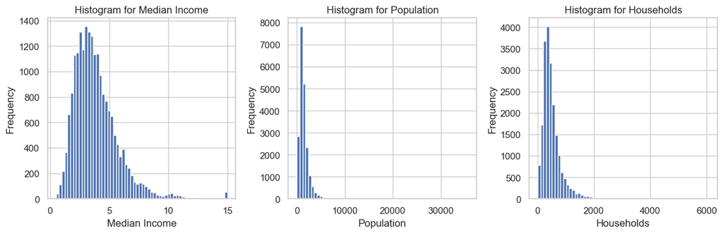

```python
import matplotlib.pyplot as plt
# in order to show plots in a single figure we are using subplots in matplotlib
fig, axes = plt.subplots(nrows=1, ncols=3, figsize=(12,4))

# Histogram for Median Income
axes[0].hist(housing_df[median_income_cn], bins=60)
axes[0].set_xlabel('Median Income')
axes[0].set_ylabel('Frequency')
axes[0].set_title('Histogram for Median Income')

#Histogram for Population
axes[1].hist(housing_df[population_cn], bins=60)
axes[1].set_xlabel('Population')
axes[1].set_ylabel('Frequency')
axes[1].set_title('Histogram for Population')

#Histogram for Households
axes[2].hist(housing_df[n_household_cn], bins=60)
axes[2].set_xlabel('Households')
axes[2].set_ylabel('Frequency')
axes[2].set_title('Histogram for Households')

plt.tight_layout()
plt.show()
```

> We can see that there is an anomaly in distribution closing towards the maximum for Median Income Histogram. In order to explore more we can use a scatter plot for median_income and check.

> We can also see that there is a possibility for a relation between Households and Population since the histogram is almost similar in shape.

```python
# We are using seaborn to plot scatter plots
import seaborn as sns
# To eliminate warnings from appearing in ipynb
import warnings
warnings.filterwarnings('ignore')

# created a function for plotting scatter diagram which uses seaborn.
def plot_scatter_diagram(df, x_axis_column_name, y_axis_column_name, title, xlabel, ylabel):
    sns.set(style="whitegrid", color_codes=True)
    sns.jointplot(x=x_axis_column_name, y=y_axis_column_name, data=df)
    plt.title(title)
    plt.xlabel(xlabel)
    plt.ylabel(ylabel)
    plt.tight_layout()
    plt.show()
    return
```

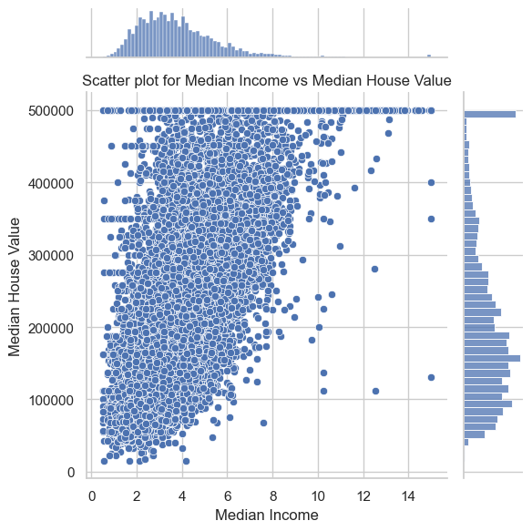

```python
plot_scatter_diagram(housing_df, 'median_income', 'median_house_value',
                     'Scatter plot for Median Income vs Median House Value',
                     'Median Income', 'Median House Value')
```

Here we can actually see that there is a possibility that the maximum value for median house value might be having a cap. Here again its confirmed that there is an abnormal frequency of maximum values.

```python
median_house_value_cn = 'median_house_value'
# finding top 5 most occuring value of median_house_value
most_frequent = housing_df[median_house_value_cn].value_counts().head(5)
print(f'Values with highest frequencies : \n{most_frequent}')

max_value_median_income = housing_df[median_house_value_cn].max()
print(f'Max Value for median house value {max_value_median_income}')
```

```
Values with highest frequencies :
median_house_value
500001.0    965
137500.0    122
162500.0    117
112500.0    103
187500.0     93
Name: count, dtype: int64
Max Value for median house value 500001.0
```

> > We can see that there is a phenomenol difference between frequency of 1st and 2nd most frequent **median_house_value**. Also the most frequently appearing anomaly is also the maximum value which suggests that there might have been a capping or limit in median house value which we need to eliminate for avoiding skewing.

```python
housing_df_processed = housing_df[housing_df.median_house_value != 500001]
print(len(housing_df_processed))
```

```
19675
```

Checking if the anomalities are removed now

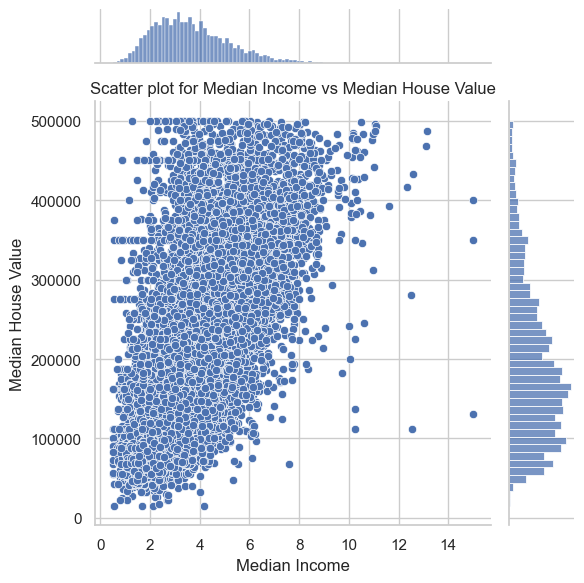

```python
#note that here for plotting we are using processed dataframe.
plot_scatter_diagram(housing_df_processed, "median_income", "median_house_value",
                     'Scatter plot for Median Income vs Median House Value',
                     'Median Income', 'Median House Value')
```

Checking Scatter plots for any anomalies for population

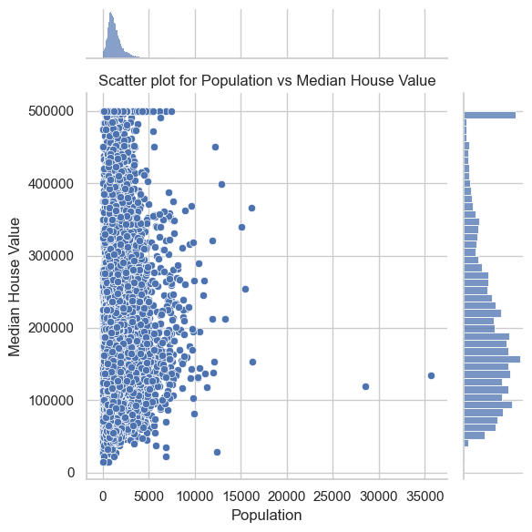

```python
plot_scatter_diagram(housing_df, "population", "median_house_value",
                     'Scatter plot for Population vs Median House Value',
                     'Population', 'Median House Value')
```

Checking if the anomaly in the maximum of median house value is resolved in the previously processed data frame

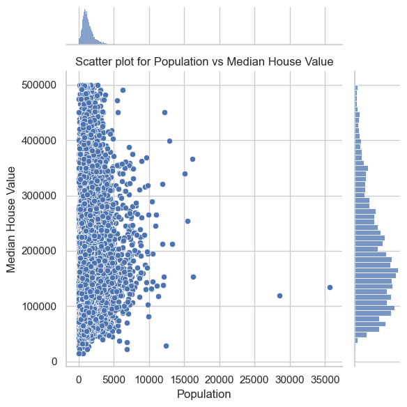

```python
plot_scatter_diagram(housing_df_processed, "population", "median_house_value",
                     'Scatter plot for Population vs Median House Value',
                     'Population', 'Median House Value')
```

##### Checking for anomalies in number of households

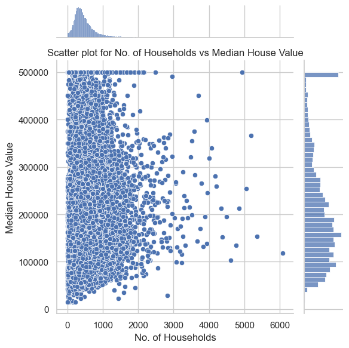

```python
plot_scatter_diagram(housing_df, "households", "median_house_value",
                     'Scatter plot for No. of Households vs Median House Value',
                     'No. of Households', 'Median House Value')
```

Checking if the above abnormality is solved in the processed dataframe

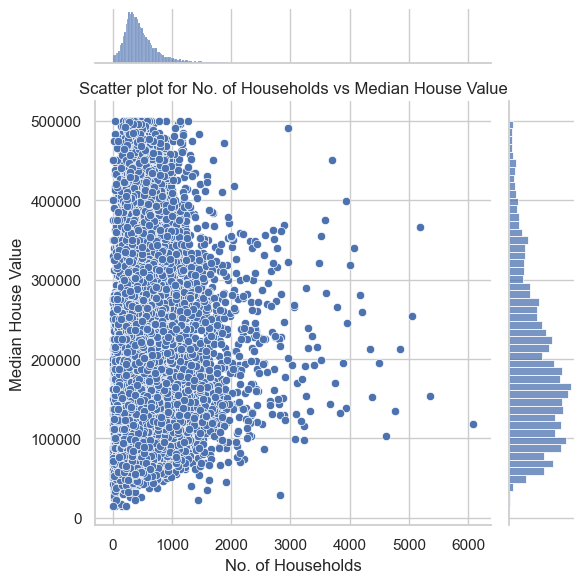

```python
plot_scatter_diagram(housing_df_processed, "households", "median_house_value",
                     'Scatter plot for No. of Households vs Median House Value',
                     'No. of Households', 'Median House Value')
```

#### **3.5 Summary of Data Overview**

- Removed capped housing values of 50001 so that it doesn't skew the models. This reduced the total datapoints from 20640 to 19675. Not a significant difference.
- There is a good possibility for a linear relationship between income and housing value from the scatter plot graph.
- There is less chance for a good linear regression model from population and household variables.
- The outliers will definitely increase the error for population and household linear regression model.
- Number of households range from 0 - 6000, Population ranges from 0 to 35682 and Median Income ranges from 0.5 to 15
- Examining the third quartile we understand that population and household variable are not evenly distributed. For population ratio of 3rd quartile and max value is almost 20 times. For household variable 3rd quartile and max value is almost 10 times. This can possibly skew these 2 models towards erronous predictions.

### **4. Modeling**

##### **4.1 Splitting dataset into training and test dataset**

```python
# In order to split data frame into two sets
# training and test dataset we need to import scikit learning library 'model_selection' module.
# We can just split using array split options also but then it won't be randomized. The usage of the following function from scikit
# allows to specify a random_state parameter which promises reproducibility even when the split is randomized. ie. If same dataset is passed to the train_test_split
# function with the same parameter values and random_state key then the split would always be identical.

from sklearn.model_selection import train_test_split

training_df, test_df = train_test_split(housing_df_processed, test_size=0.2, random_state=25)
print(f'Training set count : {len(training_df)}')
print(f'Test set count : {len(test_df)}')
```

```
Training set count : 15740
Test set count : 3935
```

#### **4.2 Creating Linear Regression Model**

```python
from sklearn.linear_model import LinearRegression

# Linear regression model for all three independent variable
lrm_median_income = LinearRegression()
lrm_median_income.fit(training_df[['median_income']], training_df[['median_house_value']])

lrm_population = LinearRegression()
lrm_population.fit(training_df[['population']], training_df[['median_house_value']])

lrm_households = LinearRegression()
lrm_households.fit(training_df[['households']], training_df[['median_house_value']])
```

```
LinearRegression()
```

#### **4.3 Intercepts and Error for the three models**

##### **Training Set**

```python
#importing mean_squared_error and mean_absolute_error from scikit learn library
from sklearn.metrics import mean_squared_error, mean_absolute_error

intercept_lrm_median_income = lrm_median_income.intercept_
coeff_lrm_median_income = lrm_median_income.coef_
mse_lrm_median_income = mean_squared_error(training_df[['median_house_value']], lrm_median_income.predict(training_df[['median_income']]))
mae_lrm_median_income = mean_absolute_error(training_df[['median_house_value']], lrm_median_income.predict(training_df[['median_income']]))

intercept_lrm_population = lrm_population.intercept_
coef_lrm_population = lrm_population.coef_
mse_lrm_population = mean_squared_error(training_df[['median_house_value']], lrm_population.predict(training_df[['population']]))
mae_lrm_population = mean_absolute_error(training_df[['median_house_value']], lrm_population.predict(training_df[['population']]))

intercept_lrm_households = lrm_households.intercept_
coef_lrm_households = lrm_households.coef_
mse_lrm_households = mean_squared_error(training_df[['median_house_value']], lrm_households.predict(training_df[['households']]))
mae_lrm_households = mean_absolute_error(training_df[['median_house_value']], lrm_households.predict(training_df[['households']]))

model_data = {
    'Parameter': ['Median Income', 'Population', 'Number of Households', ],
    'Intercept': [intercept_lrm_median_income, intercept_lrm_population, intercept_lrm_households],
    'Coefficient': [coeff_lrm_median_income, coef_lrm_population, coef_lrm_households],
    'Mean Squared Error': [mse_lrm_median_income, mse_lrm_population, mse_lrm_households],
    'Mean Absolute Error': [mae_lrm_median_income, mae_lrm_population, mae_lrm_households],
}

model_df = pd.DataFrame(model_data)
```

##### **Table of Values - Training Set**

```python
display(model_df)
mean_of_house_value = training_df['median_house_value'].mean()
print(f'The mean value of median_house_value is {mean_of_house_value}')
```

|  | Parameter | Intercept | Coefficient | Mean Squared Error | Mean Absolute Error |
| --- | --- | --- | --- | --- | --- |
| 0 | Median Income | [45152.43428421224] | [[40008.14569216125]] | 5.622604e+09 | 56867.213971 |
| 1 | Population | [190771.42426087247] | [[0.9153586605844272]] | 9.557957e+09 | 78258.439132 |
| 2 | Number of Households | [180078.759012484] | [[24.043914232122233]] | 9.475214e+09 | 77789.222385 |

```
The mean value of median_house_value is 192088.09383735704
```

##### **Test Set**

```python
#importing mean_squared_error and mean_absolute_error from scikit learn library
from sklearn.metrics import mean_squared_error, mean_absolute_error

mse_lrm_median_income_test = mean_squared_error(test_df[['median_house_value']], lrm_median_income.predict(test_df[['median_income']]))
mae_lrm_median_income_test = mean_absolute_error(test_df[['median_house_value']], lrm_median_income.predict(test_df[['median_income']]))

mse_lrm_population_test = mean_squared_error(test_df[['median_house_value']], lrm_population.predict(test_df[['population']]))
mae_lrm_population_test = mean_absolute_error(test_df[['median_house_value']], lrm_population.predict(test_df[['population']]))

mse_lrm_households_test = mean_squared_error(test_df[['median_house_value']], lrm_households.predict(test_df[['households']]))
mae_lrm_households_test = mean_absolute_error(test_df[['median_house_value']], lrm_households.predict(test_df[['households']]))

model_data_test = {
    'Parameter': ['Median Income', 'Population', 'Number of Households', ],
    'Mean Squared Error': [mse_lrm_median_income_test, mse_lrm_population_test, mse_lrm_households_test],
    'Mean Absolute Error': [mae_lrm_median_income_test, mae_lrm_population_test, mae_lrm_households_test],
}

model_df_test = pd.DataFrame(model_data_test)
```

##### **Table of Values - Test Set**

```python
display(model_df_test)
mean_of_house_value = test_df['median_house_value'].mean()
print(f'The mean value of median_house_value is {mean_of_house_value}')
```

|  | Parameter | Mean Squared Error | Mean Absolute Error |
| --- | --- | --- | --- |
| 0 | Median Income | 5.532658e+09 | 56525.271116 |
| 1 | Population | 9.497434e+09 | 78162.191183 |
| 2 | Number of Households | 9.405185e+09 | 77624.216126 |

```
The mean value of median_house_value is 194037.22973316393
```

### **5. Evaluation**

#### **5.1 Plots**

```python
import numpy as np
import warnings
import math

def scatter_plot_with_regression_line(testdf, trainingdf, lrm, x_column_name,
                                      y_column_name, title_test, title_training,
                                      xlabel, ylabel, mse_test, mae_test, mse_training, mae_training):
    warnings.filterwarnings('ignore')
    fig, ax = plt.subplots(1, 2, figsize=(10,5))
    sns.scatterplot(x=x_column_name, y=y_column_name, data=test_df, color="red", ax=ax[0])
    ax[0].set_title(title_test)
    ax[0].set_xlabel(xlabel)
    ax[0].set_ylabel(ylabel)
    ax[0].text(x=5, y=10, s=f"Intercept : {lrm.intercept_}\nCoefficient : {lrm.coef_} \nMSE Test : {mse_test}\nMAE Test: {mae_test}")
    ax[1].text(x=5, y=10, s=f"\nMSE Training : {mse_training}\nMAE Training: {mae_training}")


    sns.scatterplot(x=x_column_name, y=y_column_name, data=training_df, color="blue", ax=ax[1])
    ax[1].set_title(title_training)
    ax[1].set_xlabel(xlabel)
    ax[1].set_ylabel(ylabel)



    #Creating a np array and then converting into dataframe for use in sns line plot function.
    # This had to be done since plt line plot was not working with two columns in a single row for plot graph
    actual_test_values = test_df[[x_column_name]]
    predicted_test_house_values = lrm.predict(actual_test_values)
    np_predicted_test = np.hstack((actual_test_values, predicted_test_house_values))
    df_np_predicted_test = pd.DataFrame(np_predicted_test, columns=[xlabel, ylabel])

    actual_training_values = training_df[[x_column_name]]
    predicted_training_house_values = lrm.predict(actual_training_values)
    np_predicted_training = np.hstack((actual_training_values, predicted_training_house_values))
    df_np_predicted_training = pd.DataFrame(np_predicted_training, columns=[xlabel, ylabel])

    sns.lineplot(data=df_np_predicted_test, x=xlabel, y=ylabel, color="black", ax=ax[0])
    sns.lineplot(data=df_np_predicted_training, x=xlabel, y=ylabel, color="black", ax=ax[1])
    plt.tight_layout()
    plt.show()
    return
```

##### **5.1.1 Median Income vs Median House Value**

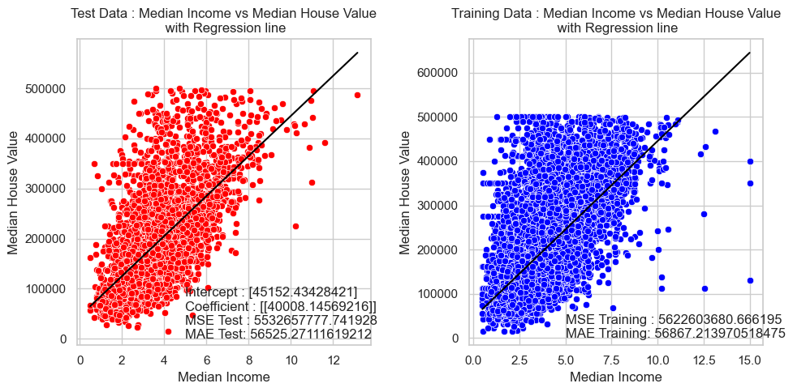

```python
scatter_plot_with_regression_line(test_df, training_df, lrm_median_income,
                                'median_income', 'median_house_value',
                                'Test Data : Median Income vs Median House Value\n with Regression line',
                                'Training Data : Median Income vs Median House Value\n with Regression line',
                                'Median Income', 'Median House Value',
                                mse_lrm_median_income_test, mae_lrm_median_income_test,
                                mse_lrm_median_income, mae_lrm_median_income)
```

##### **5.1.2 Population vs Median House Value**

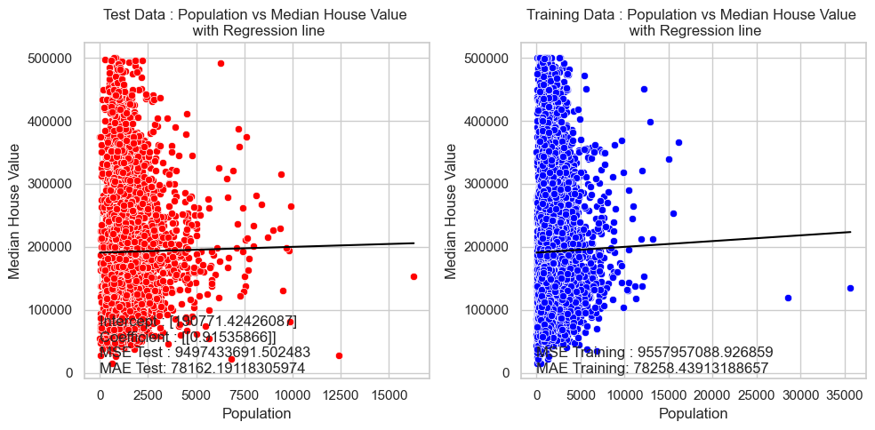

```python
scatter_plot_with_regression_line(test_df, training_df, lrm_population,
                                'population', 'median_house_value',
                                'Test Data : Population vs Median House Value \n with Regression line',
                                'Training Data : Population vs Median House Value \n with Regression line',
                                'Population', 'Median House Value',
                                mse_lrm_population_test, mae_lrm_population_test,
                                mse_lrm_population, mae_lrm_population)
```

#### **5.1.3 Number of Households vs Median House Value**

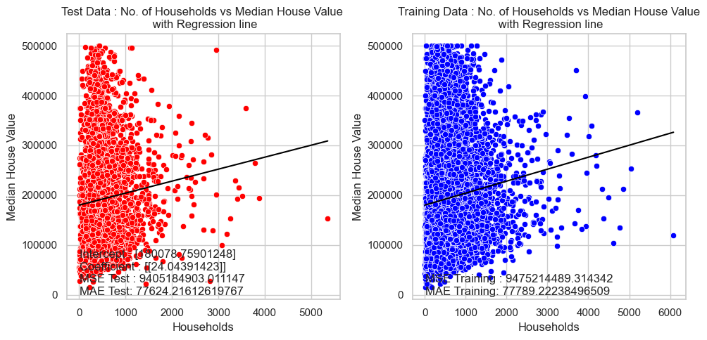

```python
scatter_plot_with_regression_line(test_df, training_df, lrm_households,
                                'households', 'median_house_value',
                                'Test Data : No. of Households vs Median House Value \n with Regression line',
                                'Training Data : No. of Households vs Median House Value\n with Regression line',
                                'Households', 'Median House Value',
                                mse_lrm_households_test, mae_lrm_households_test,
                                mse_lrm_households, mae_lrm_households)
```

#### **5.2 Analysis**

##### **5.2.1 Error Ratio**

Calculating error ratio from mean absolute error and mean value

> Error ratio is calculated by dividing Mean Absolute Error by Mean Value of the parameter.

```python
from math import atan, degrees
from sklearn.metrics import r2_score

error_ratio = pd.DataFrame({'ErrorRatio': [(mae_lrm_median_income_test/mean_of_house_value)*100, (mae_lrm_population_test/mean_of_house_value)*100, (mae_lrm_households_test/mean_of_house_value)*100]})
```

##### **5.2.2 RMSE - Root Mean Squared Error**

```python
rmse = pd.DataFrame({'RMSE': [(np.sqrt(mse_lrm_median_income_test)), np.sqrt(mse_lrm_population_test), np.sqrt(mse_lrm_households_test)]})
```

##### **5.2.3 R-Squared**

rsquared is a value that denotes the variance of housing value based on each parameter.

- value close to 0 suggests a weak relation with the independent parameter.
- value close to 1 suggests a strong relation with the independent parameter.

```python
actual_test_values_median_house_values = test_df[['median_house_value']]
actual_test_values_median_income = test_df[['median_income']]
predicted_test_house_values_median_income = lrm_median_income.predict(actual_test_values_median_income)
rsquared_median_income = r2_score(actual_test_values_median_house_values, predicted_test_house_values_median_income)

actual_test_values_population = test_df[['population']]
predicted_test_house_values_population = lrm_population.predict(actual_test_values_population)
rsquared_population = r2_score(actual_test_values_median_house_values, predicted_test_house_values_population)

actual_test_values_households = test_df[['households']]
predicted_test_house_values_households = lrm_households.predict(actual_test_values_households)
rsquared_households = r2_score(actual_test_values_median_house_values, predicted_test_house_values_households)

rsquared = pd.DataFrame({'RMSE': [rsquared_median_income, rsquared_population, rsquared_households]})
```

Combining all of the above calculated values into a dataframe

```python
combined = np.hstack((model_df_test, error_ratio, rmse, rsquared))
summary_df = pd.DataFrame(combined, columns=['Parameter', 'MSE', 'MAE', 'Error Ratio between MAE and Mean', 'RMSE', 'R-Squared'])
display(summary_df)
```

|  | Parameter | MSE | MAE | Error Ratio between MAE and Mean | RMSE | R-Squared |
| --- | --- | --- | --- | --- | --- | --- |
| 0 | Median Income | 5532657777.741928 | 56525.271116 | 29.131147 | 74381.837687 | 0.417371 |
| 1 | Population | 9497433691.502483 | 78162.191183 | 40.282059 | 97454.777674 | -0.000149 |
| 2 | Number of Households | 9405184903.011147 | 77624.216126 | 40.004805 | 96980.332558 | 0.009565 |

### **6. Conclusion**

From the scatter plots with regression lines and error ratio the following things can be concluded.

- **Median Income** offers the **best result in predicting Median House Value**. The error percentage from mean is **~29%**. Even though this is also a huge error comparatively this parameter offers a **better result in prediction than Population and No. of Household**.
- Population and No of households have a high error of prediction ie. close to 40%. So when comparing the three these 2 should be least used for prediction of Median House Value.
- **Root mean squared Error (RMSE)** is least for Median Income. This also suggests that out of the three parameters Median Income is the better parameter for predicting housing value.
- **R-squared** is in **negative value for Population** which suggests that its a **really bad model for predicting house value**. So we should not use it at all for prediction.
- **R-Squared** is close to zero for **households** which indicates that its **not good in predicting the house values**.
- **R-Squared** even though not close to 1, **Median Income is better than the other 2**. The value is 0.4 which suggests that the prediction using just Median Income should be taken with enough space for error or that there are more work to be done on fine tuning the model for prediction.